# Titanic_Project

This analysis aims to explore the data on the passengers aboard the ship 'Titanic', and will try to look for various factors which may have influenced the survival rate for a given passenger

```python
#Importing various libraries to be used
import pandas as pd
import numpy as np
%matplotlib inline
import matplotlib.pyplot as plt
import seaborn as sns
```

```python
#Importing the CSV data as a Pandas dataframe, and checking the first few rows to get a sense of the data structure
t_df = pd.read_csv('titanic-data.csv')
t_df.head()
```

|  | PassengerId | Survived | Pclass | Name | Sex | Age | SibSp | Parch | Ticket | Fare | Cabin | Embarked |
| --- | --- | --- | --- | --- | --- | --- | --- | --- | --- | --- | --- | --- |
| 0 | 1 | 0 | 3 | Braund, Mr. Owen Harris | male | 22.0 | 1 | 0 | A/5 21171 | 7.2500 | NaN | S |
| 1 | 2 | 1 | 1 | Cumings, Mrs. John Bradley (Florence Briggs Th... | female | 38.0 | 1 | 0 | PC 17599 | 71.2833 | C85 | C |
| 2 | 3 | 1 | 3 | Heikkinen, Miss. Laina | female | 26.0 | 0 | 0 | STON/O2. 3101282 | 7.9250 | NaN | S |
| 3 | 4 | 1 | 1 | Futrelle, Mrs. Jacques Heath (Lily May Peel) | female | 35.0 | 1 | 0 | 113803 | 53.1000 | C123 | S |
| 4 | 5 | 0 | 3 | Allen, Mr. William Henry | male | 35.0 | 0 | 0 | 373450 | 8.0500 | NaN | S |

With this data, I would like to be able to answer the following questions

1.Was there a link between age group & survival rate

2.Was the sex of the person a factor affecting the survival rate

3.Was there a link between the passenger ticket class and rate of survival

4.Was a person travelling alone more likely to survive or one travelling in a group ( either with a sibling or a spouse)

```python
#DATA WRANGLING
t_df.describe()#First look at some insights into the data
```

|  | PassengerId | Survived | Pclass | Age | SibSp | Parch | Fare |
| --- | --- | --- | --- | --- | --- | --- | --- |
| count | 891.000000 | 891.000000 | 891.000000 | 714.000000 | 891.000000 | 891.000000 | 891.000000 |
| mean | 446.000000 | 0.383838 | 2.308642 | 29.699118 | 0.523008 | 0.381594 | 32.204208 |
| std | 257.353842 | 0.486592 | 0.836071 | 14.526497 | 1.102743 | 0.806057 | 49.693429 |
| min | 1.000000 | 0.000000 | 1.000000 | 0.420000 | 0.000000 | 0.000000 | 0.000000 |
| 25% | 223.500000 | 0.000000 | 2.000000 | 20.125000 | 0.000000 | 0.000000 | 7.910400 |
| 50% | 446.000000 | 0.000000 | 3.000000 | 28.000000 | 0.000000 | 0.000000 | 14.454200 |
| 75% | 668.500000 | 1.000000 | 3.000000 | 38.000000 | 1.000000 | 0.000000 | 31.000000 |
| max | 891.000000 | 1.000000 | 3.000000 | 80.000000 | 8.000000 | 6.000000 | 512.329200 |

The count of Age is less than the count for other varibales (714 vs 891). Upon checking, it turns out that there are some rows where ages is blank. I will need to remove these to make the data consistent.

```python
#Data Wrangling
t_df=t_df.dropna(subset=['Age'])#Drop all rows where age is NaN
t_df.describe()
```

|  | PassengerId | Survived | Pclass | Age | SibSp | Parch | Fare |
| --- | --- | --- | --- | --- | --- | --- | --- |
| count | 714.000000 | 714.000000 | 714.000000 | 714.000000 | 714.000000 | 714.000000 | 714.000000 |
| mean | 448.582633 | 0.406162 | 2.236695 | 29.699118 | 0.512605 | 0.431373 | 34.694514 |
| std | 259.119524 | 0.491460 | 0.838250 | 14.526497 | 0.929783 | 0.853289 | 52.918930 |
| min | 1.000000 | 0.000000 | 1.000000 | 0.420000 | 0.000000 | 0.000000 | 0.000000 |
| 25% | 222.250000 | 0.000000 | 1.000000 | 20.125000 | 0.000000 | 0.000000 | 8.050000 |
| 50% | 445.000000 | 0.000000 | 2.000000 | 28.000000 | 0.000000 | 0.000000 | 15.741700 |
| 75% | 677.750000 | 1.000000 | 3.000000 | 38.000000 | 1.000000 | 1.000000 | 33.375000 |
| max | 891.000000 | 1.000000 | 3.000000 | 80.000000 | 5.000000 | 6.000000 | 512.329200 |

# Data Wrangling

Now the count is same for all columns, and i can begin my data exploration

Question 1: Link between age and survival rate

To make the analysis easier, I am dividing all passengers into age groups

Child (0-15), Young (16-25) , Adult(26-50) , Aged (50+)

```python
#Q1 : Defining a function which returns an age range depending on the value

def age_range(x):
    if 0 <= x['Age'] <= 15 :
        return 'Child (0-15)'
    elif 16 <= x['Age'] <= 25:
        return 'Young (16-25)'
    elif 26 <= x['Age'] <= 50:
        return 'Adult (26-50)'
    elif x['Age'] >51:
        return 'Aged (50+)'

#Applying this function to create a new column in the dataframe
t_df['Age_Range']=t_df.apply(age_range, axis='columns')
t_df.head()
```

|  | PassengerId | Survived | Pclass | Name | Sex | Age | SibSp | Parch | Ticket | Fare | Cabin | Embarked | Age_Range |
| --- | --- | --- | --- | --- | --- | --- | --- | --- | --- | --- | --- | --- | --- |
| 0 | 1 | 0 | 3 | Braund, Mr. Owen Harris | male | 22.0 | 1 | 0 | A/5 21171 | 7.2500 | NaN | S | Young (16-25) |
| 1 | 2 | 1 | 1 | Cumings, Mrs. John Bradley (Florence Briggs Th... | female | 38.0 | 1 | 0 | PC 17599 | 71.2833 | C85 | C | Adult (26-50) |
| 2 | 3 | 1 | 3 | Heikkinen, Miss. Laina | female | 26.0 | 0 | 0 | STON/O2. 3101282 | 7.9250 | NaN | S | Adult (26-50) |
| 3 | 4 | 1 | 1 | Futrelle, Mrs. Jacques Heath (Lily May Peel) | female | 35.0 | 1 | 0 | 113803 | 53.1000 | C123 | S | Adult (26-50) |
| 4 | 5 | 0 | 3 | Allen, Mr. William Henry | male | 35.0 | 0 | 0 | 373450 | 8.0500 | NaN | S | Adult (26-50) |

```python
# Q1 : Link between age range & Survival Rate
t_df.corr()['Survived']
```

```
PassengerId    0.029340
Survived       1.000000
Pclass        -0.359653
Age           -0.077221
SibSp         -0.017358
Parch          0.093317
Fare           0.268189
Name: Survived, dtype: float64
```

There is a slightly negativa correlation between age and survival rate. Let me the distribute the data into age groups and see the results

```python
# Q1 : Link between age range & Survival Rate
p_age_range=t_df.groupby(['Age_Range'])
Age_Range_survival=p_age_range['Survived'].sum()/p_age_range['PassengerId'].count()*100 #Finding Survival rate
Age_Range_survival=Age_Range_survival.sort_values(ascending=False)
Age_Range_survival
```

```
Age_Range
Child (0-15)     59.036145
Adult (26-50)    41.260745
Aged (50+)       35.087719
Young (16-25)    34.403670
dtype: float64
```

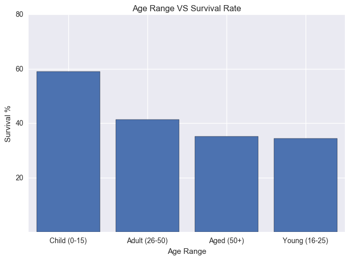

```python
#Insights Q1: Visualizing the results
plt.bar(range(len(Age_Range_survival)),Age_Range_survival,align='center')
plt.xticks(range(len(Age_Range_survival)),list(Age_Range_survival.index.values))
plt.yticks([20,40,60,80])
plt.xlabel('Age Range')
plt.ylabel('Survival %')
plt.title('Age Range VS Survival Rate')
```

Conclusion Q1: The highest survival rate was for children (0-15yrs), followed by adults(26-50yrs). Although correlation does not imply causation, it could be a possibility that children were given first priority on the life boats.

```python
# Q2 : Link between Passenger Sex and survival rate
p_sex=t_df.groupby('Sex')#Grouping by sex
sex_survival=p_sex['Survived'].sum()/p_sex['PassengerId'].count()*100
print sex_survival
```

```
Sex
female    75.478927
male      20.529801
dtype: float64
```

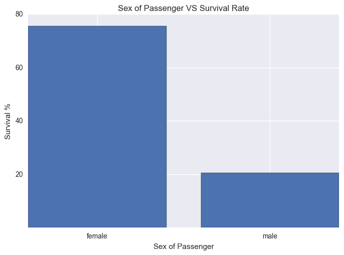

```python
# Q2 : Visiualization and Insights
plt.bar(range(len(sex_survival)),sex_survival,align='center')
plt.xticks(range(len(sex_survival)),list(sex_survival.index.values))
plt.yticks([20,40,60,80])
plt.xlabel('Sex of Passenger')
plt.ylabel('Survival %')
plt.title('Sex of Passenger VS Survival Rate')
```

Conclusion Q2: Female passengers had a survival rate of almost 4 times that of male passengers. Although, correlation does not directly imply causation, it is a possibility that females were given preference while being loaded into the lifeboats.

```python
# Q3 : Link between Passenger Class & Survival Rate
pclass=t_df.groupby('Pclass')
class_survival=pclass['Survived'].sum()/pclass['PassengerId'].count()*100
print class_survival
```

```
Pclass
1    65.591398
2    47.976879
3    23.943662
dtype: float64
```

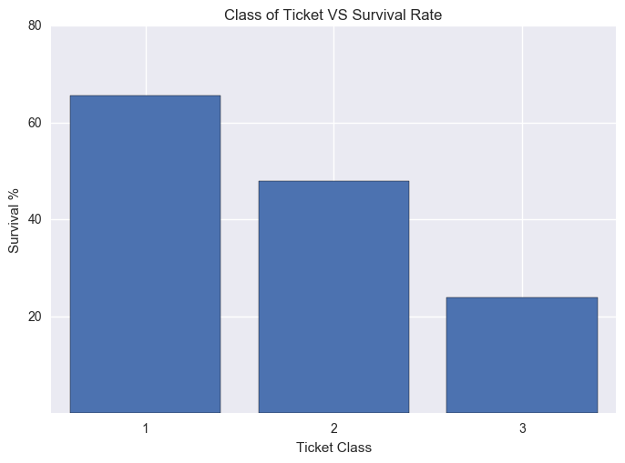

```python
#Q3: Insights & Visualizations
plt.bar(range(len(class_survival)),class_survival,align='center')
plt.xticks(range(len(class_survival)),list(class_survival.index.values))
plt.yticks([20,40,60,80])
plt.xlabel('Ticket Class')
plt.ylabel('Survival %')
plt.title('Class of Ticket VS Survival Rate')
```

# Q3: Conclusion

Although correlation does not imply causation, it could be a possibility that higher class passengers were given priority access to life saving means like lifeboat access and life jackets

Q4 Link between Travelling Alone & Survival Rate

For answering this question, I would need to know whether the passenger was travelling alone or in a group. Hence, I will create a new column, which will depend on the values of SibSp and Parch. If both these columns (SibSp, Parch) are 0, this would imply that the passenger was travelling alone. (this ignores the exceptional cases of children travelling with nannies or people accompanied by mistresses)

```python
#Q4 Defining a function which returns 1 or 0 to travelling alone column
def passenger_alone(x):
    if x['SibSp'] ==0 and x["Parch"] == 0:
        return 1
    else:
        return 0
#Applying this function to create a new column 'Alone'
t_df['alone']=t_df.apply(passenger_alone, axis='columns')
```

```python
# Q4 : Link between Traveling Alone & Survival Rate
p_alone=t_df.groupby('alone')
alone_survival=p_alone['Survived'].sum()/p_alone['PassengerId'].count()*100
print alone_survival
```

```
alone
0    51.612903
1    32.178218
dtype: float64
```

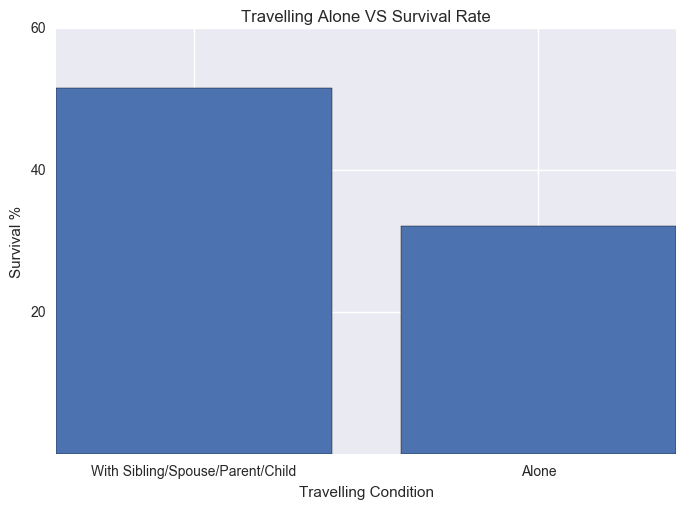

```python
# Q4 : Visualizations & Insights
plt.bar(range(len(alone_survival)),alone_survival,align='center')
plt.xticks(range(len(alone_survival)),['With Sibling/Spouse/Parent/Child','Alone'])
plt.yticks([20,40,60])
plt.xlabel('Travelling Condition')
plt.ylabel('Survival %')
plt.title('Travelling Alone VS Survival Rate')
```

# Q4 Conclusion

Although correlation does not always imply causation, one potential reason could be the travel companions helped each other in surviving i.e. watching out for dangers

# Limitations

This analysis of the data suffers from the following limitations

1. Certain rows of data with missing age values were removed from the analysis
2. The travelling alone variable does not take into account passengers who were travelling with nannies or passengers who were travelling with mistresses or finaces

# Conclusion: Multiple Variable View

```python
#Multiple Variable View
p_cluster=t_df.groupby(['Age_Range','Sex'])
cluster_survival=p_cluster['Survived'].sum()/p_cluster['PassengerId'].count()*100
cluster_survival=cluster_survival.sort_values(ascending=False)
print cluster_survival
```

```
Age_Range      Sex
Aged (50+)     female    93.750000
Adult (26-50)  female    77.049180
Young (16-25)  female    74.683544
Child (0-15)   female    65.116279
               male      52.500000
Adult (26-50)  male      22.026432
Aged (50+)     male      12.195122
Young (16-25)  male      11.510791
dtype: float64
```

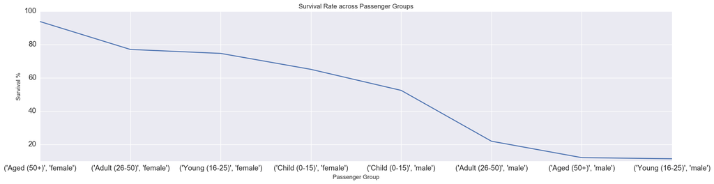

```python
# Plotting the groups VS survival rates
plt.figure(figsize=(21,5))
fig=plt.plot(range(len(cluster_survival[:])),cluster_survival[:])
plt.xticks(range(len(cluster_survival[:])),list(cluster_survival.index.values)[:])
plt.yticks([20,40,60,80,100])
plt.xlabel('Passenger Group')
plt.ylabel('Survival %')
plt.title('Survival Rate across Passenger Groups')
plt.tick_params(axis='both',which='major',labelsize=13.5)
```

# Conclusion

Looking at overall view of the data, we can get some indications as to how these variables affect one another.

The highest survival rates tend to be amongst older females.

The lowest survival rates tend to be amongst younger males.

Although one cannot assume causation, it does seem that the Sex and Age have a major impact on survival rate.